# density_gradient_lowcis

### Simulating signaling under a density gradient

Now we will use our DDE solver to calculate the model-predicted fluorescence under these conditions.

We randomly assign 1% of cells to be sender cells to mimic the 1:100 sender:transceiver co-culture. We fix the random seed for reproducibility, but one can repeat this process with different seeds to show that the gross behavior is minimally affected.

**Set sender cell location**

```python
# Specify percent of population that is sender
pct_s = 1
n_s = int(n * (pct_s/100)) + 1

# Set seed
np.random.seed(seed)

# Assign senders randomly
sender_idx = np.random.choice(n, n_s, replace=False)
```

**Get RHS of signaling DDE**

```python
# Get RHS of DDE equation to pass to integrator
rhs = lsig.get_DDE_rhs(rhs_long, sender_idx, beta_func, beta_args,)
```

Transceivers are initialized at zero-state initial conditions, and senders are fixed at a fluorescence of `1` (by definition).

Since our parameter `L` (pairwise contact area) varies over time, we use the `lsig.integrate_DDE_varargs` solver, short for "variable argument(s)."

```python
# Set initial conditions
S0 = np.zeros(n)
S0[sender_idx] = 1

# Perform integration (method of steps)
S_t = lsig.integrate_DDE_varargs(
    t,
    rhs,
    var_vals=wA_t,
    dde_args=(*dde_args, wA_t[0]),
    E0=S0,
    delay=delay,
    progress_bar=True,
    min_delay=5,
    where_vars=7,
)
```

#### Visualizing a simulated kinematic wave

In order to mimic the appearance of the experiment, we construct a mask of cells inside a circle, similar to the circular culture well.

```python
# Make mask of cells inside circle
X_dists = np.linalg.norm(X - np.array([0, y_k/2]), axis=1)
X_mask = np.array([d <= y_k/2 for d in X_dists])

# Set fluorescence to zero outside circle
S_t_cir = S_t.copy()
for i in range(nt):
    S_t_cir[i, ~X_mask] = 0
```

We would like to construct a Voronoi mesh and color each cell with its fluorescence value. However, this is not practical for rendering tens to hundreds of thousands of cells per frame. Instead, we will treat each cell centroid as a point in a `ColorMesh` object and use `matplotlib` to render a continuous, interpolated heatmap.

```python
# Get plotting window
xlim = -y_k/2, y_k/2
ylim = 0, y_k
```

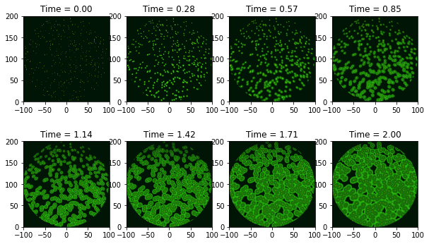

```python
import matplotlib.pyplot as plt
%matplotlib inline

# Set dimensions for a grid of frames
nrows, ncols = 2, 4

# Render frames
nplot = nrows * ncols
idx = [int(i) for i in np.linspace(0, nt-1, nplot)]
fig, axs = plt.subplots(nrows=nrows, ncols=ncols, figsize=(10,6))
for ax, i in zip(axs.flat, idx):
    title=f"Time = {t[i]:.2f}"
    lsig.inspect_colormesh(
        ax=ax,
        X=X,
        rows=rows,
        cols=cols,
        var=S_t_cir,
        idx=i,
        vmin=0,
        vmax=1,
        cmap="kgy",
        xlim=xlim,
        ylim=ylim,
        title=title,
    )
```